### Data

- 자료 구성

```r
library(xlsx)
```

```r
library(pander)
library(ggplot2)
options(digits=3)
quiz1109 <- read.xlsx("../data/class_roll1109.xlsx", 1, startRow = 2, endRow = 72, colIndex = c(3:7, 9:13), colClasses=rep("character", 10))
str(quiz1109)
```

```
## 'data.frame':    68 obs. of  10 variables:
##  $ 학과              : chr  "언론" "재무금융학과" "경영학부" "광고홍보학과" ...
##  $ 학.직.번          : chr  "20128005" "20113201" "20152802" "20152652" ...
##  $ 이름              : chr  "ANGIRMAA GANBAT" "강용석" "구준하" "권나라" ...
##  $ 학년              : chr  "4" "2" "1" "1" ...
##  $ E.Mail            : chr  "angiraa@yahoo.com" "dragonstone_@outlook.com" "powerpigs@naver.com" "922nara@naver.com" ...
##  $ 핸드폰번호        : chr  "010-9661-8787" "010-5047-8327" "010-9481-7743" "010-8949-7343" ...
##  $ 지역승수.LM3      : chr  NA "나" "라" "라" ...
##  $ 다음.도표로부터   : chr  NA "라" "가" "다" ...
##  $ 낙수.효과에.대하여: chr  NA "다" "나" "라" ...
##  $ X2012년.기준      : chr  NA "나" "다" "다" ...
```

```r
names(quiz1109) <- c("dept", "id", "name", "year", "e.mail", "cell.no", "Q1", "Q2", "Q3", "Q4")
str(quiz1109)
```

```
## 'data.frame':    68 obs. of  10 variables:
##  $ dept   : chr  "언론" "재무금융학과" "경영학부" "광고홍보학과" ...
##  $ id     : chr  "20128005" "20113201" "20152802" "20152652" ...
##  $ name   : chr  "ANGIRMAA GANBAT" "강용석" "구준하" "권나라" ...
##  $ year   : chr  "4" "2" "1" "1" ...
##  $ e.mail : chr  "angiraa@yahoo.com" "dragonstone_@outlook.com" "powerpigs@naver.com" "922nara@naver.com" ...
##  $ cell.no: chr  "010-9661-8787" "010-5047-8327" "010-9481-7743" "010-8949-7343" ...
##  $ Q1     : chr  NA "나" "라" "라" ...
##  $ Q2     : chr  NA "라" "가" "다" ...
##  $ Q3     : chr  NA "다" "나" "라" ...
##  $ Q4     : chr  NA "나" "다" "다" ...
```

```r
q.ans <- quiz1109[paste("Q", 1:4, sep="")]
q.ans.lm3 <- factor(q.ans$Q1, levels=c("가", "나", "다", "라"), labels=c("12억", "20억", "25억", "30억"))
q.ans.mtr.top.income <- factor(q.ans$Q2, levels=c("가", "나", "다", "라"), labels=c("높고높다", "낮고낮다", "높고낮다", "높으면낮다"))
q.ans.trickle.down <- factor(q.ans$Q3, levels=c("가", "나", "다", "라"), labels=c("있다", "없다", "있는 듯", "계층별"))
q.ans.coop.agri <- factor(q.ans$Q4, levels=c("가", "나", "다", "라"), labels=c("일본 전농", "한국 농협", "미국 CHS", "뉴질랜드 폰테라"))
```

- 응답 내용 분석
  - 지역승수에 대한 인식 양호(정답률 : 57%)
  - 최고소득세율과 상위1% 소득점유율의 관계에 대한 인식 대폭 개선(정답률 34% => 49% => 72%, 연관성이 곧 인과관계가 아님을 인식해 가는 중)
  - ’낙수’효과에 대한 인식 제자리(정답률 : 51% => 67% => 77% => 72% => 75%)
  - 농식품분야 한국 농업협동조합의 위상에 대한 인식 개선(정답률 : 36% => 67%)

```r
load("../R/quiz1028v2.rda")
quiz1109.div <- data.frame(quiz1028.div[, 1:7], quiz1109[c("Q1", "Q2", "Q3", "Q4")])
pander(table(quiz1109.div$college, quiz1109.div$Q1))
```

|  | 나 | 다 | 라 |
| --- | --- | --- | --- |
| **경영대학** | 4 | 2 | 12 |
| **사회과학대학** | 1 | 8 | 6 |
| **인문대학** | 1 | 1 | 5 |
| **자연과학대학** | 0 | 2 | 6 |
| **정보전자공과대학** | 1 | 4 | 3 |

```r
pander(table(quiz1109.div$college, quiz1109.div$Q2))
```

|  | 가 | 나 | 다 | 라 |
| --- | --- | --- | --- | --- |
| **경영대학** | 1 | 1 | 13 | 3 |
| **사회과학대학** | 0 | 1 | 10 | 4 |
| **인문대학** | 0 | 0 | 5 | 2 |
| **자연과학대학** | 0 | 0 | 7 | 2 |
| **정보전자공과대학** | 0 | 1 | 6 | 1 |

```r
pander(table(quiz1109.div$college, quiz1109.div$Q3))
```

|  | 가 | 나 | 다 | 라 |
| --- | --- | --- | --- | --- |
| **경영대학** | 2 | 11 | 2 | 3 |
| **사회과학대학** | 0 | 12 | 1 | 2 |
| **인문대학** | 1 | 4 | 0 | 2 |
| **자연과학대학** | 1 | 8 | 0 | 0 |
| **정보전자공과대학** | 0 | 8 | 0 | 0 |

```r
pander(table(quiz1109.div$college, quiz1109.div$Q4))
```

|  | 가 | 나 | 다 | 라 |
| --- | --- | --- | --- | --- |
| **경영대학** | 1 | 12 | 2 | 3 |
| **사회과학대학** | 0 | 8 | 1 | 6 |
| **인문대학** | 0 | 6 | 0 | 1 |
| **자연과학대학** | 1 | 6 | 1 | 1 |
| **정보전자공과대학** | 0 | 6 | 0 | 2 |

```r
pander(mapply(function(x) xtabs(~college + x, data=quiz1109.div), quiz1109.div[c("Q1", "Q2", "Q3", "Q4")], SIMPLIFY = FALSE))
```

- **Q1**:

  |  | 나 | 다 | 라 |
  | --- | --- | --- | --- |
  | **경영대학** | 4 | 2 | 12 |
  | **사회과학대학** | 1 | 8 | 6 |
  | **인문대학** | 1 | 1 | 5 |
  | **자연과학대학** | 0 | 2 | 6 |
  | **정보전자공과대학** | 1 | 4 | 3 |

- **Q2**:

  |  | 가 | 나 | 다 | 라 |
  | --- | --- | --- | --- | --- |
  | **경영대학** | 1 | 1 | 13 | 3 |
  | **사회과학대학** | 0 | 1 | 10 | 4 |
  | **인문대학** | 0 | 0 | 5 | 2 |
  | **자연과학대학** | 0 | 0 | 7 | 2 |
  | **정보전자공과대학** | 0 | 1 | 6 | 1 |

- **Q3**:

  |  | 가 | 나 | 다 | 라 |
  | --- | --- | --- | --- | --- |
  | **경영대학** | 2 | 11 | 2 | 3 |
  | **사회과학대학** | 0 | 12 | 1 | 2 |
  | **인문대학** | 1 | 4 | 0 | 2 |
  | **자연과학대학** | 1 | 8 | 0 | 0 |
  | **정보전자공과대학** | 0 | 8 | 0 | 0 |

- **Q4**:

  |  | 가 | 나 | 다 | 라 |
  | --- | --- | --- | --- | --- |
  | **경영대학** | 1 | 12 | 2 | 3 |
  | **사회과학대학** | 0 | 8 | 1 | 6 |
  | **인문대학** | 0 | 6 | 0 | 1 |
  | **자연과학대학** | 1 | 6 | 1 | 1 |
  | **정보전자공과대학** | 0 | 6 | 0 | 2 |

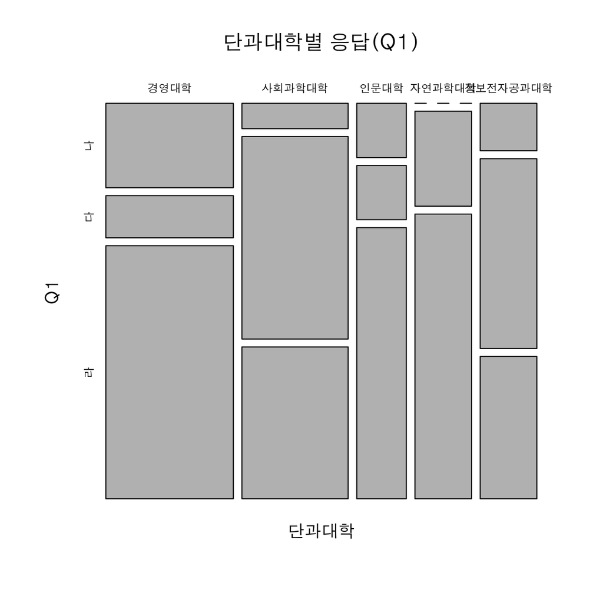

```r
mosaicplot(table("단과대학"=quiz1109.div$college, "Q1"=quiz1109.div$Q1), main="단과대학별 응답(Q1)")
```

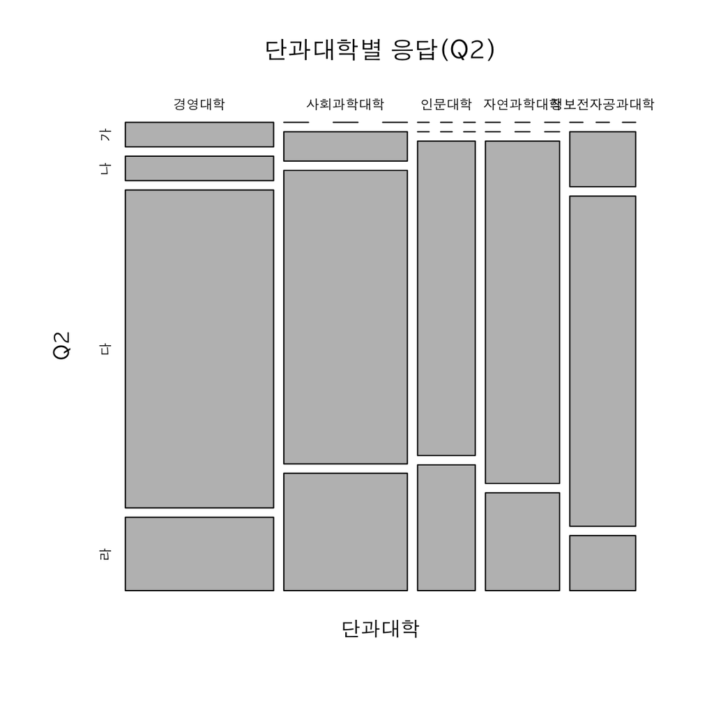

```r
mosaicplot(table("단과대학"=quiz1109.div$college, "Q2"=quiz1109.div$Q2), main="단과대학별 응답(Q2)")
```

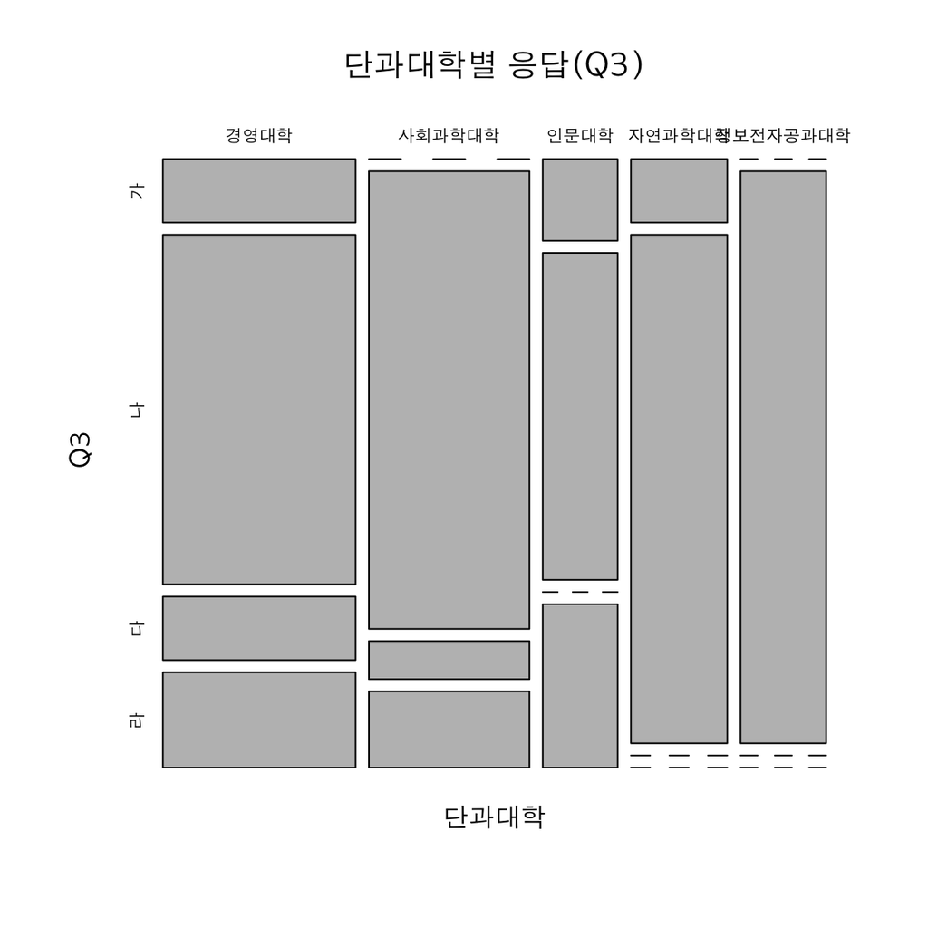

```r
mosaicplot(table("단과대학"=quiz1109.div$college, "Q3"=quiz1109.div$Q3), main="단과대학별 응답(Q3)")
```

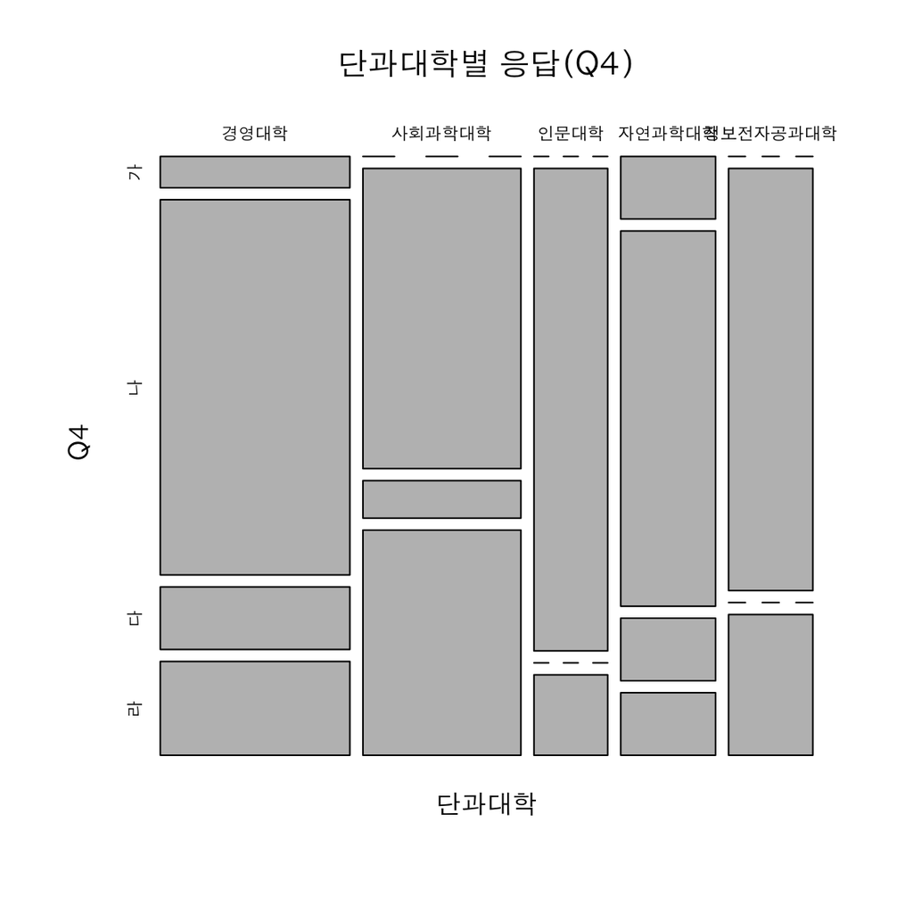

```r
mosaicplot(table("단과대학"=quiz1109.div$college, "Q4"=quiz1109.div$Q4), main="단과대학별 응답(Q4)")
```

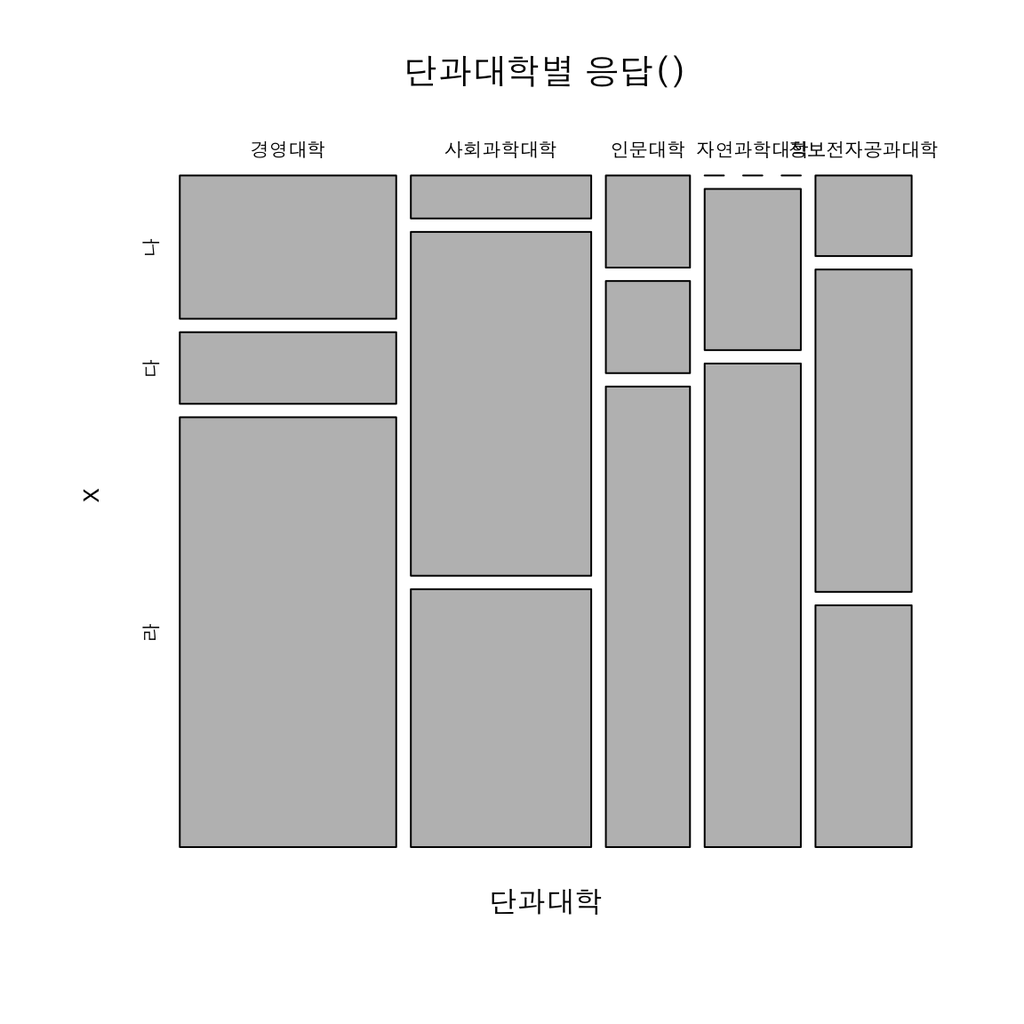

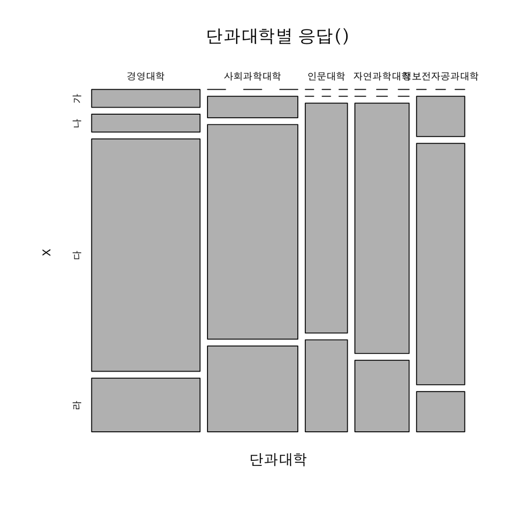

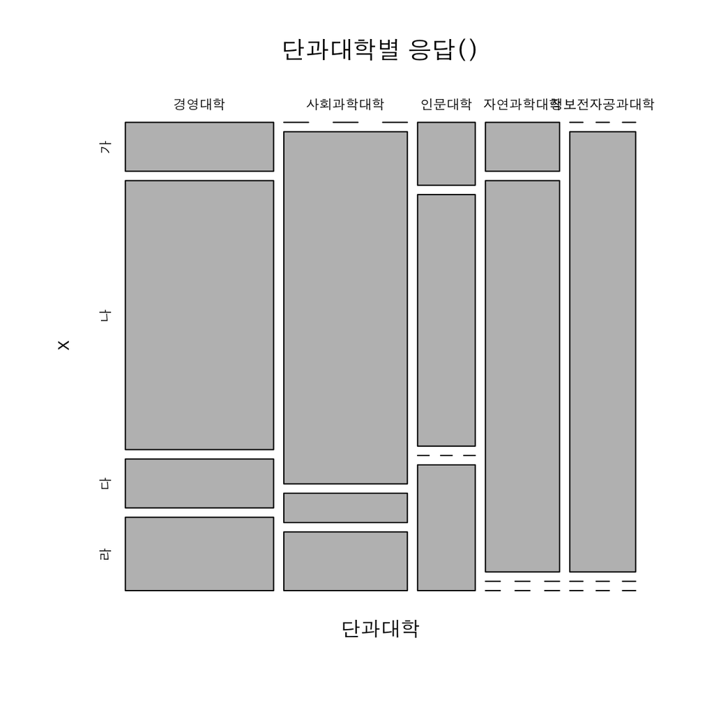

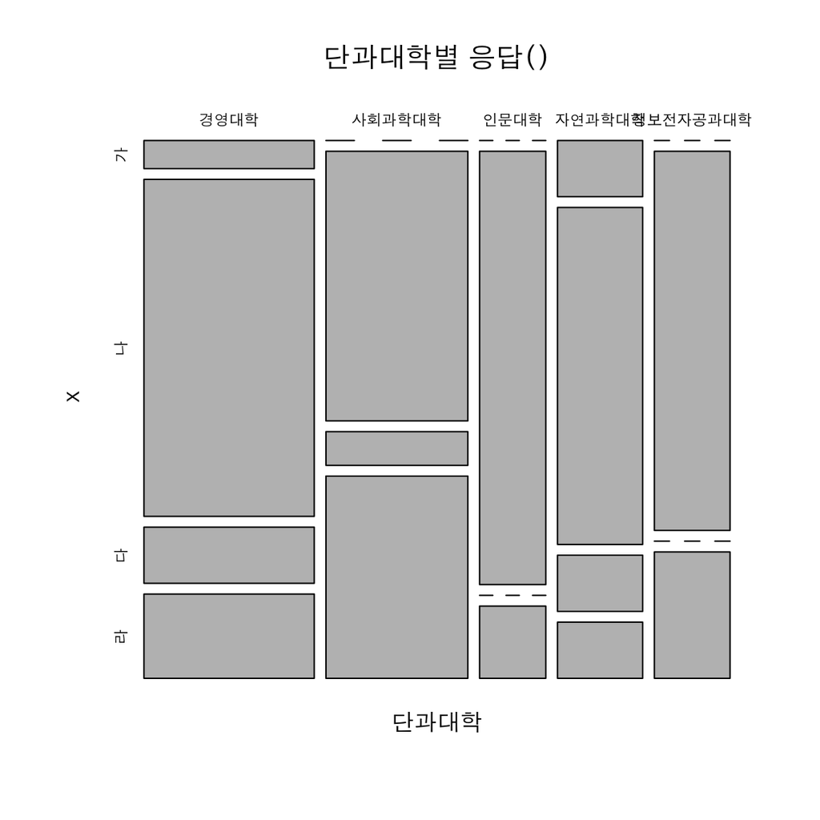

```r
mapply(function(x) mosaicplot(xtabs(~college + x, data=quiz1109.div), main=paste("단과대학별 응답(", dimnames(x)[[2]],")", sep=""), xlab = "단과대학", ylab = names(x)), quiz1109.div[c("Q1", "Q2", "Q3", "Q4")])
```

```r
q.ans.tbl <- apply(q.ans, 2, table, useNA="ifany")
pander(q.ans.tbl)
```

- **Q1**:

  | 나 | 다 | 라 | NA |
  | --- | --- | --- | --- |
  | 7 | 17 | 32 | 12 |

- **Q2**:

  | 가 | 나 | 다 | 라 | NA |
  | --- | --- | --- | --- | --- |
  | 1 | 3 | 41 | 12 | 11 |

- **Q3**:

  | 가 | 나 | 다 | 라 | NA |
  | --- | --- | --- | --- | --- |
  | 4 | 43 | 3 | 7 | 11 |

- **Q4**:

  | 가 | 나 | 다 | 라 | NA |
  | --- | --- | --- | --- | --- |
  | 2 | 38 | 4 | 13 | 11 |

```r
pander(table(q.ans.lm3))
```

| 12억 | 20억 | 25억 | 30억 |
| --- | --- | --- | --- |
| 0 | 7 | 17 | 32 |

```r
pander(table(q.ans.mtr.top.income))
```

| 높고높다 | 낮고낮다 | 높고낮다 | 높으면낮다 |
| --- | --- | --- | --- |
| 1 | 3 | 41 | 12 |

```r
pander(table(q.ans.trickle.down))
```

| 있다 | 없다 | 있는 듯 | 계층별 |
| --- | --- | --- | --- |
| 4 | 43 | 3 | 7 |

```r
pander(table(q.ans.coop.agri))
```

| 일본 전농 | 한국 농협 | 미국 CHS | 뉴질랜드 폰테라 |
| --- | --- | --- | --- |
| 2 | 38 | 4 | 13 |

## 답안 분석

### 정답표와 비교

- 정답 구성
  - `mapply()`를 적용하기 위하여 정답을 `list`로 분리,

```r
q.key <- c("라", "다", "나", "나")
(q.key.l <- split(q.key, f=paste("A", 1:4, sep="")))
```

```
## $A1
## [1] "라"
##
## $A2
## [1] "다"
##
## $A3
## [1] "나"
##
## $A4
## [1] "나"
```

```r
str(q.key.l)
```

```
## List of 4
##  $ A1: chr "라"
##  $ A2: chr "다"
##  $ A3: chr "나"
##  $ A4: chr "나"
```

- 작성한 답안을 정답과 비교
  - `mapply()`에 적용하는 함수를 `factor()`와 `ifelse()`의 합성함수로 구성된 `anonymous`로 만들되, `y = q.key.l`의 default로 잡은 점에 유의.

```r
(marks <- mapply(function(x, y) factor(ifelse(x == y, "R", "W")), y = q.key.l, quiz1109[c("Q1", "Q2", "Q3", "Q4")]))
```

```
##       A1  A2  A3  A4
##  [1,] NA  NA  NA  NA
##  [2,] "W" "W" "W" "R"
##  [3,] "R" "W" "R" "W"
##  [4,] "R" "R" "W" "W"
##  [5,] "R" "W" "R" "R"
##  [6,] "R" "R" "R" "W"
##  [7,] "R" "R" "W" "W"
##  [8,] "W" "R" "R" "R"
##  [9,] "W" "W" "R" "R"
## [10,] "W" "R" "R" "R"
## [11,] "R" "W" "R" "W"
## [12,] "W" "R" "W" "R"
## [13,] "R" "R" "R" "R"
## [14,] NA  NA  NA  NA
```

[output cut: 54 more lines]

- 요약표 작성. 결석생들이 NA로 나타남.

```r
(marks.tbl <- apply(marks, 2, table, useNA="ifany"))
```

```
##      A1 A2 A3 A4
## R    32 41 43 38
## W    24 16 14 19
## <NA> 12 11 11 11
```

- 결석생들을 제외한 요약표

```r
(marks.tbl.2 <- apply(marks, 2, table))
```

```
##   A1 A2 A3 A4
## R 32 41 43 38
## W 24 16 14 19
```

### `barplot()` 작성

- `barplot()` 막대에 표시할 정답률 계산

```r
round(prop.table(marks.tbl.2, margin=2)*100, digits=1)
```

```
##     A1   A2   A3   A4
## R 57.1 71.9 75.4 66.7
## W 42.9 28.1 24.6 33.3
```

```r
(correct.ans.rate <- round(prop.table(marks.tbl.2, margin=2)[1, ]*100, digits=0))
```

```
## A1 A2 A3 A4
## 57 72 75 67
```

- `barplot()` 막대의 `names.arg`에 들어갈 이름 구성.

```r
v.names <- c("고성지역자활\nLM3파급효과", "최고소득세율과\n상위1%소득점유", "가계수지와\n낙수효과", "농식품분야\n한국농협의 위상")
```

- `barplot()` 기본 골격

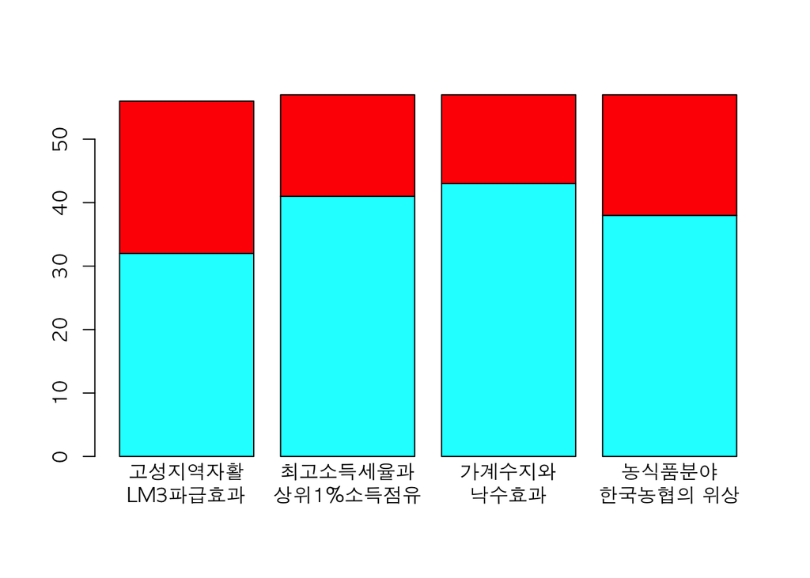

```r
barplot(marks.tbl.2, col=c("cyan", "red"), names.arg = v.names)
```

- 메인 타이틀과 x축, y축의 제목 추가

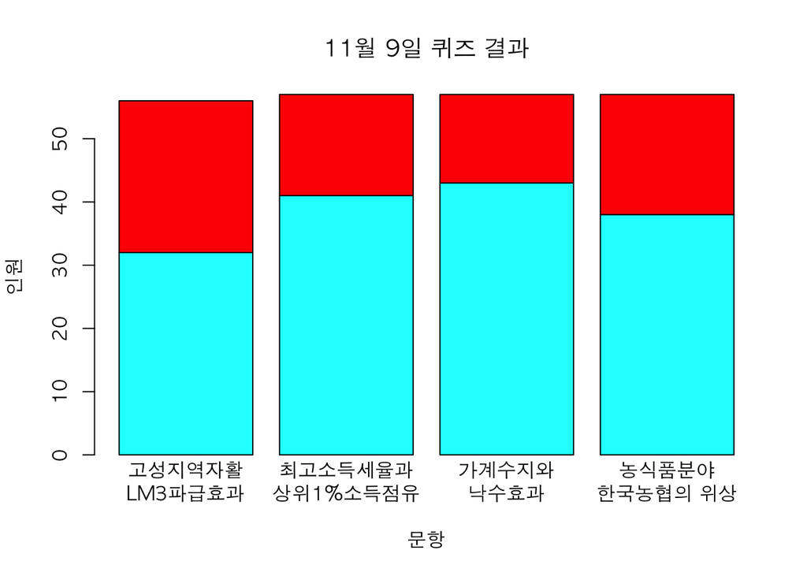

```r
barplot(marks.tbl.2, col=c("cyan", "red"), names.arg = v.names)
title(main="11월 9일 퀴즈 결과", xlab="문항", ylab="인원")
```

- 범례 추가
  - 좌표는 시행착오를 거쳐서 찾아냄.

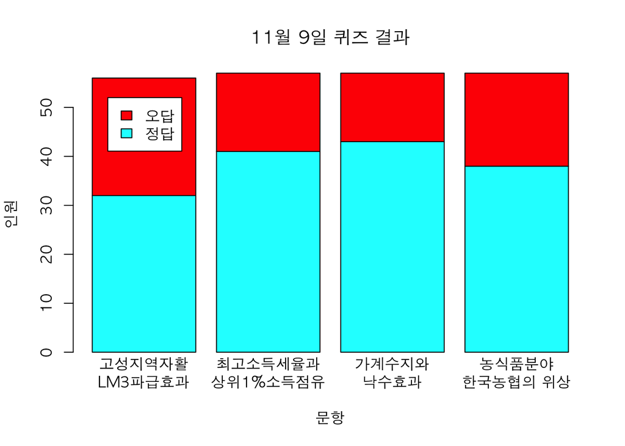

```r
barplot(marks.tbl.2, col=c("cyan", "red"), names.arg = v.names)
title(main="11월 9일 퀴즈 결과", xlab="문항", ylab="인원")
legend(x=0.35, y=52, legend=c("오답", "정답"), fill=c("red", "cyan"))
```

- 각 막대에 정답률(%) 표시
  - 좌표는 역시 시행착오를 거쳐 찾아냄.

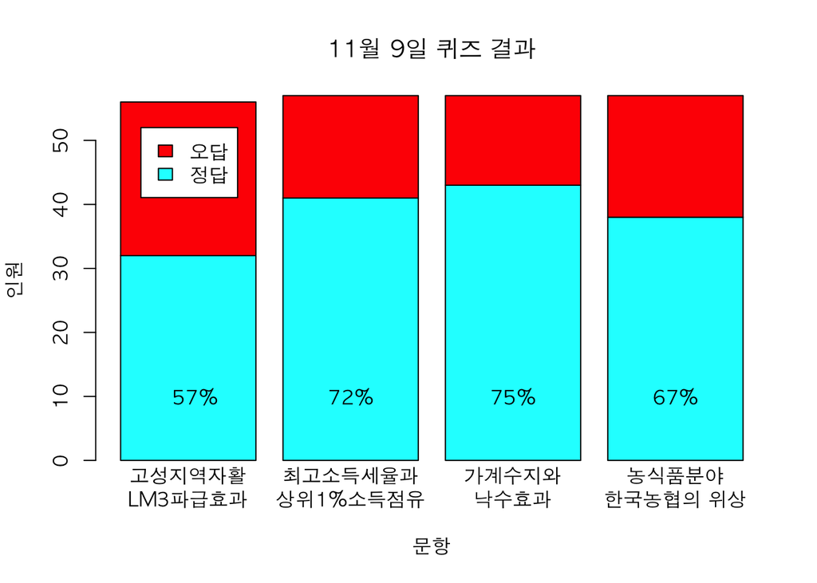

```r
barplot(marks.tbl.2, col=c("cyan", "red"), names.arg = v.names)
title(main="11월 9일 퀴즈 결과", xlab="문항", ylab="인원")
legend(x=0.35, y=52, legend=c("오답", "정답"), fill=c("red", "cyan"))
text(x=c(0.75, 1.9, 3.1, 4.3), y=rep(10, 4), labels=paste(correct.ans.rate, "%", sep=""))
```

## `ggplot()` 접근

### Two types of long format

- ggplot으로 그리려면 long format 필요
  - `marks`의 자료구조가 매트릭스이므로 `reshape2::melt`의 array(matrix, table) 유형에 적용.
  - matrix의 행이름과 열이름을 붙이는 방법에 대하여 유의하고,
  - 행이름과 열이름이 어떻게 등장하는지 살필 것.
  - `"ID"`와 `"Items"`를 `dimnames()`로 설정하지 않으면 `Var1`과 `Var2`로 나타나게 됨.
  - `value.name`을 설정하지 않으면 `value`라는 변수명을 갖게 됨. 확인해 볼 것.

```r
library(reshape2)
str(marks)
```

```
##  chr [1:68, 1:4] NA "W" "R" "R" "R" "R" "R" "W" "W" ...
##  - attr(*, "dimnames")=List of 2
##   ..$ : NULL
##   ..$ : chr [1:4] "A1" "A2" "A3" "A4"
```

```r
dimnames(marks) <- list("ID" = quiz1109$id, "Items" = dimnames(marks)[[2]])
# dimnames(marks) <- list("ID" = dimnames(marks)[[1]], "Items" = dimnames(marks)[[2]])
str(marks)
```

```
##  chr [1:68, 1:4] NA "W" "R" "R" "R" "R" "R" "W" "W" ...
##  - attr(*, "dimnames")=List of 2
##   ..$ ID   : chr [1:68] "20128005" "20113201" "20152802" "20152652" ...
##   ..$ Items: chr [1:4] "A1" "A2" "A3" "A4"
```

```r
(marks.long <- melt(marks, value.name="Marks"))
```

```
##           ID Items Marks
## 1   20128005    A1  <NA>
## 2   20113201    A1     W
## 3   20152802    A1     R
## 4   20152652    A1     R
## 5   20142510    A1     R
## 6   20121103    A1     R
## 7   20154307    A1     R
## 8   20093404    A1     W
## 9   20151401    A1     W
## 10  20112405    A1     W
## 11  20113207    A1     R
## 12  20095315    A1     W
## 13  20121109    A1     R
## 14  20132519    A1  <NA>
```

[output cut: 258 more lines]

```r
str(marks.long)
```

```
## 'data.frame':    272 obs. of  3 variables:
##  $ ID   : int  20128005 20113201 20152802 20152652 20142510 20121103 20154307 20093404 20151401 20112405 ...
##  $ Items: Factor w/ 4 levels "A1","A2","A3",..: 1 1 1 1 1 1 1 1 1 1 ...
##  $ Marks: chr  NA "W" "R" "R" ...
```

- `ggplot` 기본 골격

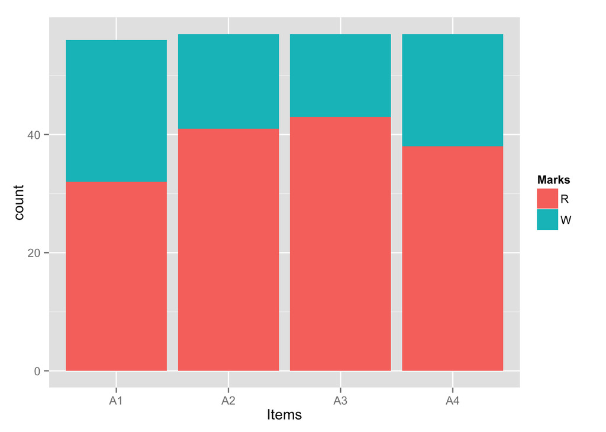

```r
(ml.1 <- ggplot(na.omit(marks.long), aes(x=Items, fill=Marks)) + geom_bar(stat="bin"))
```

- 흑백 배경 전환

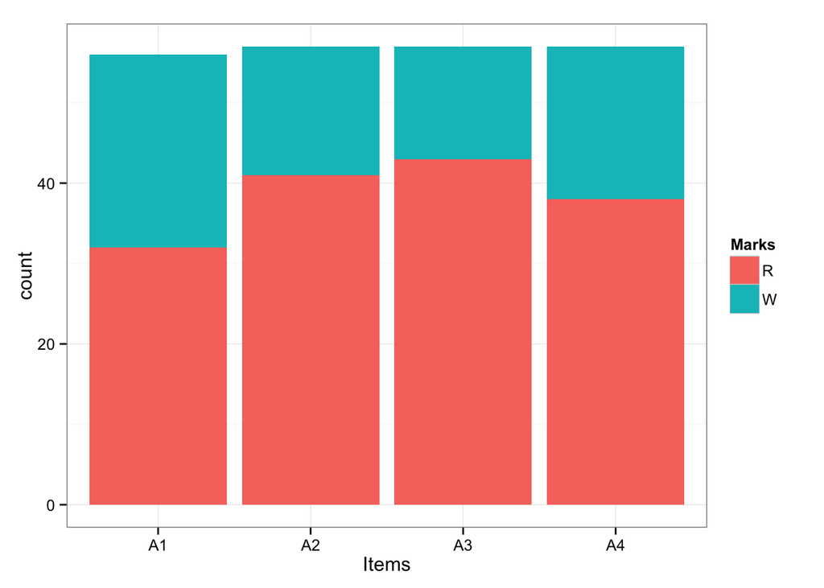

```r
(ml.2 <- ml.1 + theme_bw())
```

- 한글로 제목과 축이름 붙이기

```r
source("theme_kr_HCR.R")
ls()
```

```
##  [1] "correct.ans.rate"     "marks"                "marks.long"
##  [4] "marks.tbl"            "marks.tbl.2"          "ml.1"
##  [7] "ml.2"                 "q.ans"                "q.ans.coop.agri"
## [10] "q.ans.lm3"            "q.ans.mtr.top.income" "q.ans.tbl"
## [13] "q.ans.trickle.down"   "q.key"                "q.key.l"
## [16] "quiz1028.div"         "quiz1109"             "quiz1109.div"
## [19] "theme.HCR.kr"         "v.names"
```

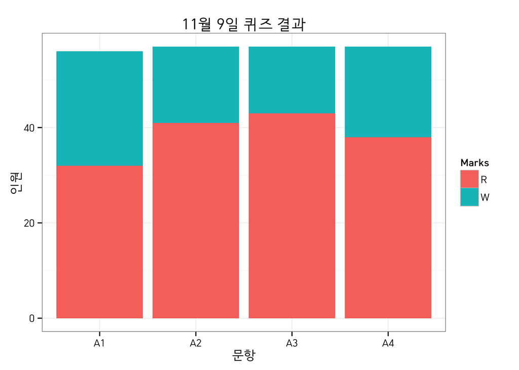

```r
(ml.3 <- ml.2 + theme.HCR.kr + xlab("문항") + ylab("인원") + ggtitle("11월 9일 퀴즈 결과"))
```

- 한글로 막대에 문항별 이름 붙이기

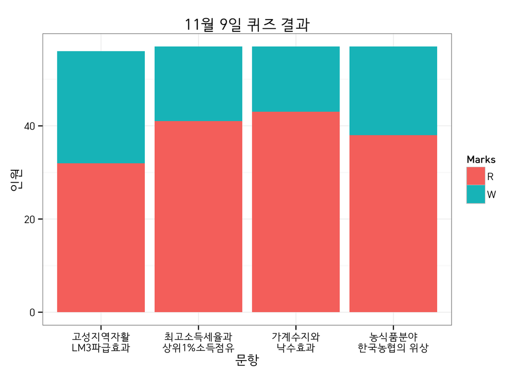

```r
(ml.4 <- ml.3 + scale_x_discrete(labels=v.names))
```

- `legend`에 한글이름 붙이기

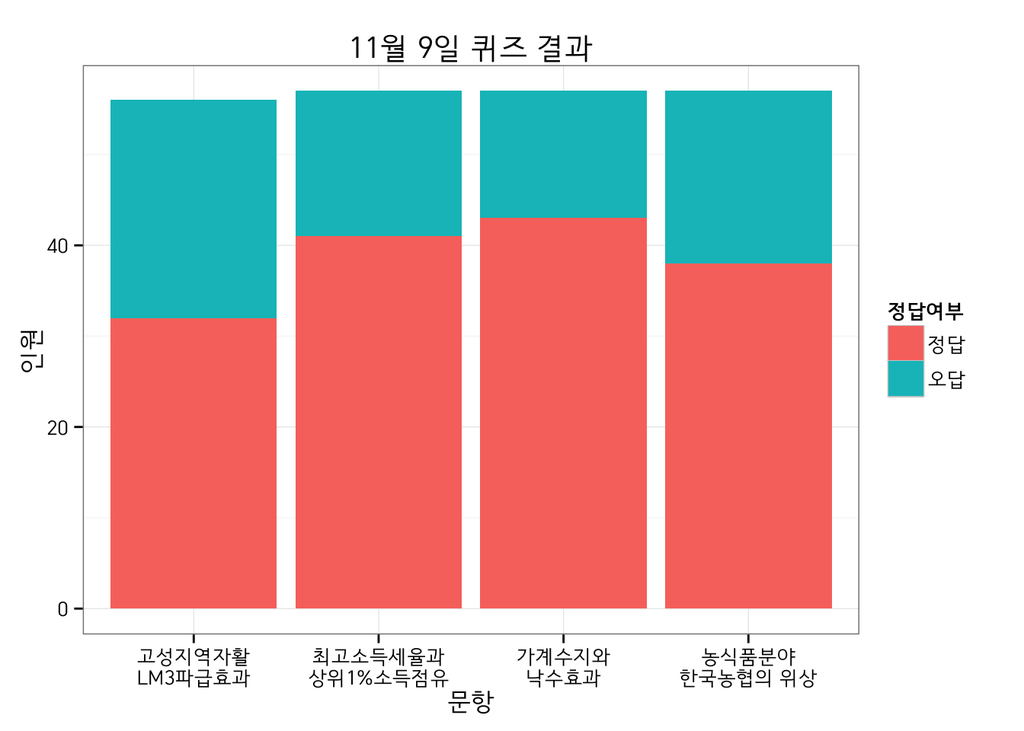

```r
(ml.5 <- ml.4 + labs(fill="정답여부") + scale_fill_discrete(labels=c("정답", "오답")))
```

- 색이 맘에 안 들면,

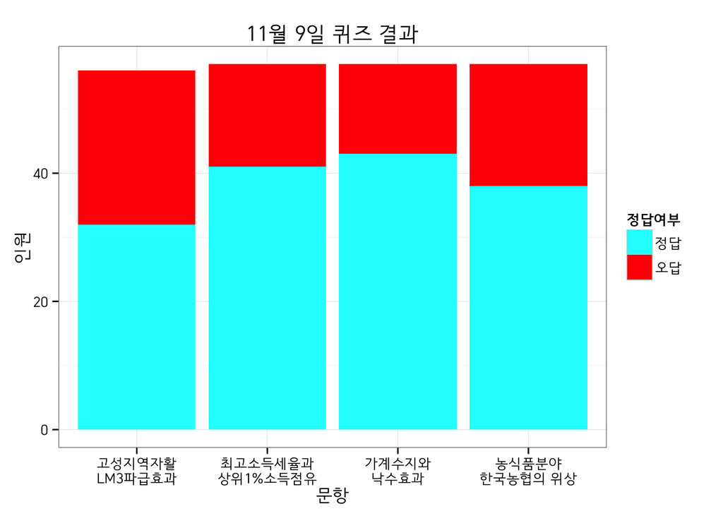

```r
(ml.6 <- ml.4 + scale_fill_manual(values=c("cyan", "red"), labels=c("정답", "오답")) + labs(fill="정답여부"))
```

- 범례 항목의 등장 순서를 바꾸려면,

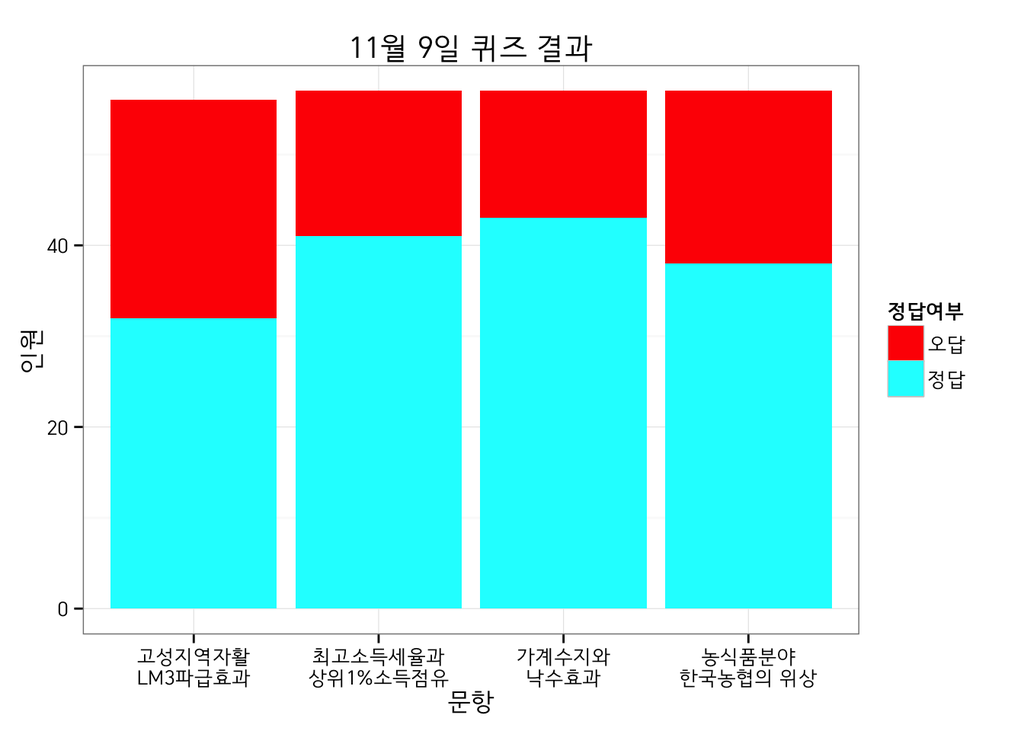

```r
(ml.7 <- ml.4 + scale_fill_manual(limits=c("W", "R"), values=c("red", "cyan"), labels=c("오답", "정답")) + labs(fill="정답여부"))
```

- 정답률을 각 막대에 새기기

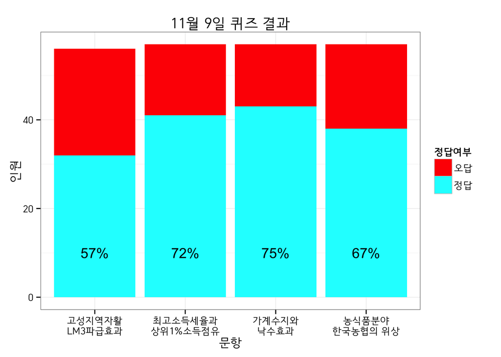

```r
(ml.8 <- ml.7 + annotate("text", x=1:4, y=rep(10, 4), label=paste(correct.ans.rate, "%", sep="")))
```

### `marks.tbl`로 그리려면,

- `marks.tbl`을 logn format으로 전환

```r
str(marks.tbl)
```

```
##  int [1:3, 1:4] 32 24 12 41 16 11 43 14 11 38 ...
##  - attr(*, "dimnames")=List of 2
##   ..$ : chr [1:3] "R" "W" NA
##   ..$ : chr [1:4] "A1" "A2" "A3" "A4"
```

```r
dimnames(marks.tbl) <- list("Marks"= dimnames(marks.tbl)[[1]], "Items" = dimnames(marks.tbl)[[2]])
str(marks.tbl)
```

```
##  int [1:3, 1:4] 32 24 12 41 16 11 43 14 11 38 ...
##  - attr(*, "dimnames")=List of 2
##   ..$ Marks: chr [1:3] "R" "W" NA
##   ..$ Items: chr [1:4] "A1" "A2" "A3" "A4"
```

```r
(marks.tbl.long <- melt(marks.tbl, value.name="Counts"))
```

```
##    Marks Items Counts
## 1      R    A1     32
## 2      W    A1     24
## 3   <NA>    A1     12
## 4      R    A2     41
## 5      W    A2     16
## 6   <NA>    A2     11
## 7      R    A3     43
## 8      W    A3     14
## 9   <NA>    A3     11
## 10     R    A4     38
## 11     W    A4     19
## 12  <NA>    A4     11
```

```r
str(marks.tbl.long)
```

```
## 'data.frame':    12 obs. of  3 variables:
##  $ Marks : Factor w/ 2 levels "R","W": 1 2 NA 1 2 NA 1 2 NA 1 ...
##  $ Items : Factor w/ 4 levels "A1","A2","A3",..: 1 1 1 2 2 2 3 3 3 4 ...
##  $ Counts: int  32 24 12 41 16 11 43 14 11 38 ...
```

- `ggplot` 골격
  - `aes()`에 `y = Counts` 등장.

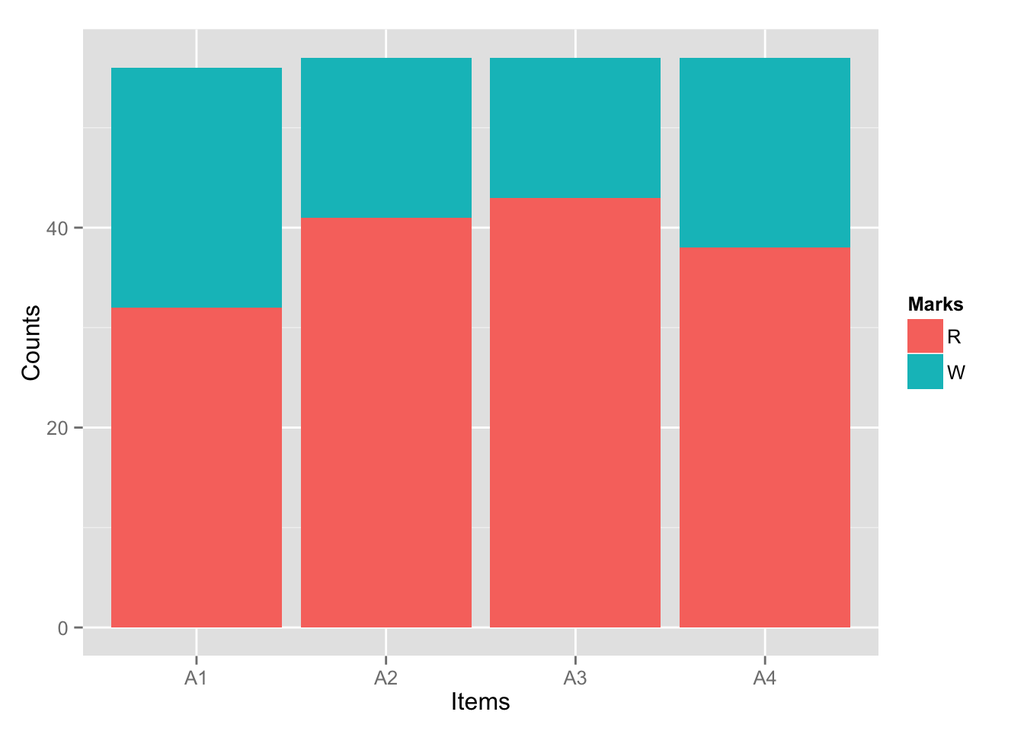

```r
(mtl.1 <- ggplot(na.omit(marks.tbl.long), aes(x = Items, y = Counts, fill = Marks)) +
  geom_bar(stat="identity"))
```

- 흑백 배경 전환

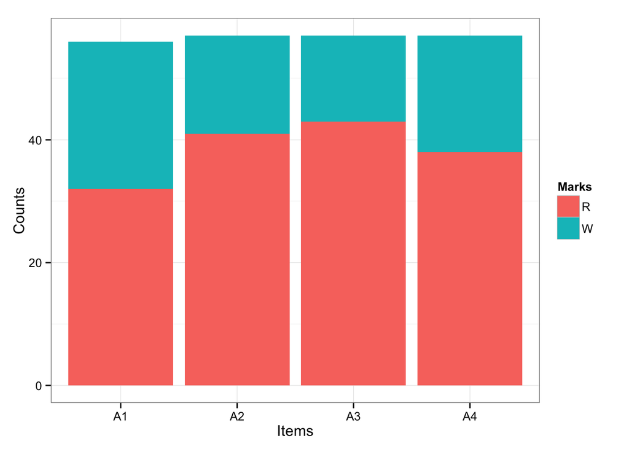

```r
(mtl.2 <- mtl.1 + theme_bw())
```

- 한글로 제목과 축이름 붙이기

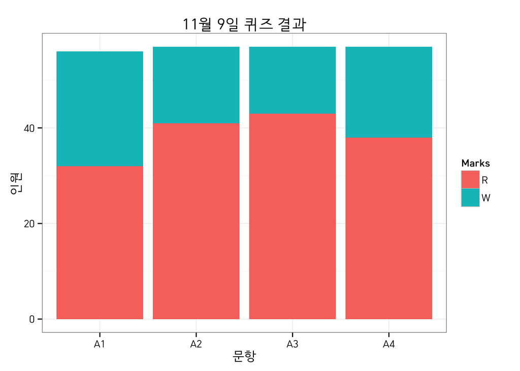

```r
(mtl.3 <- mtl.2 + theme.HCR.kr + xlab("문항") + ylab("인원") + ggtitle("11월 9일 퀴즈 결과"))
```

- 한글로 막대에 문항별 이름 붙이기

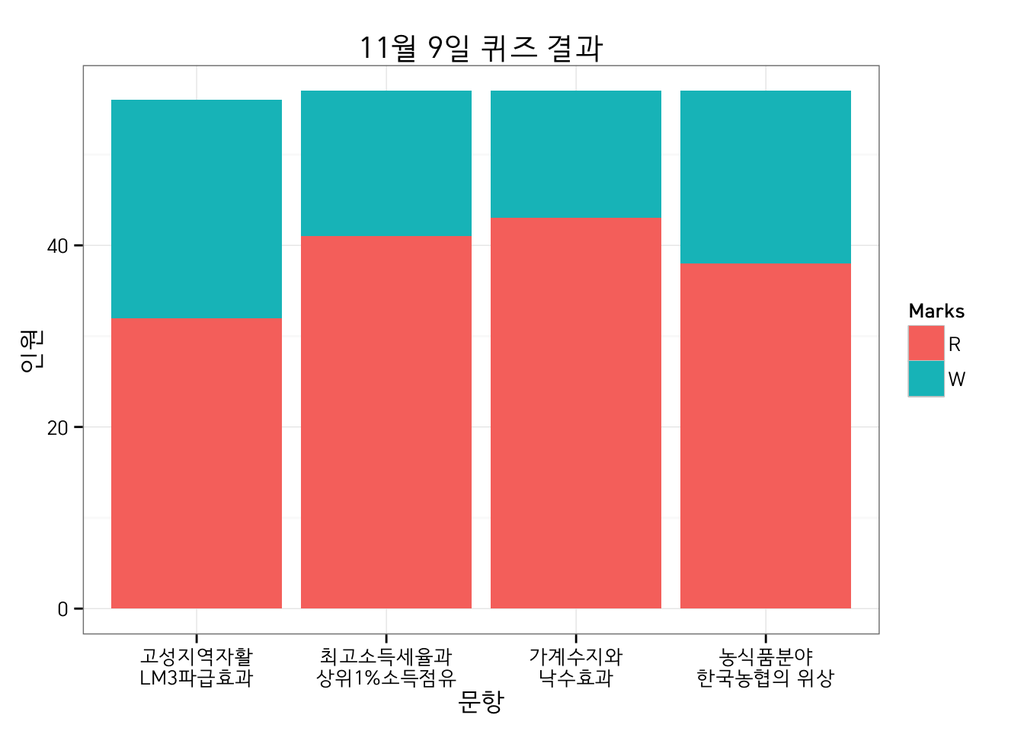

```r
(mtl.4 <- mtl.3 + scale_x_discrete(labels=v.names))
```

- `legend`에 한글이름 붙이기

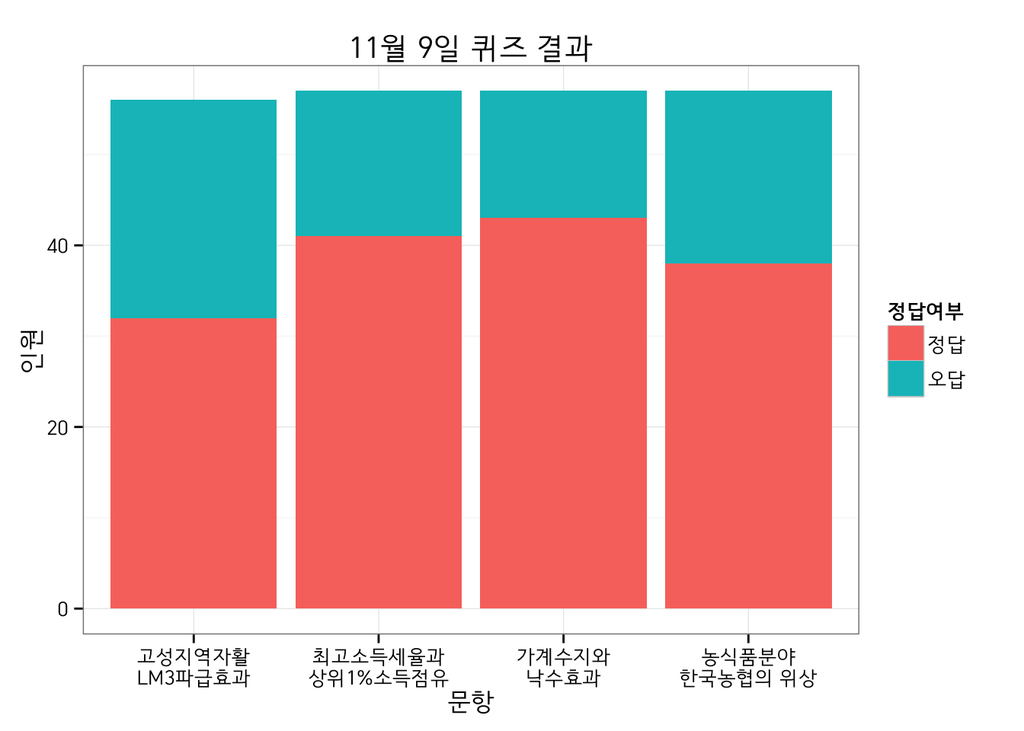

```r
(mtl.5 <- mtl.4 + labs(fill="정답여부") + scale_fill_discrete(labels=c("정답", "오답")))
```

- 색이 맘에 안 들면,

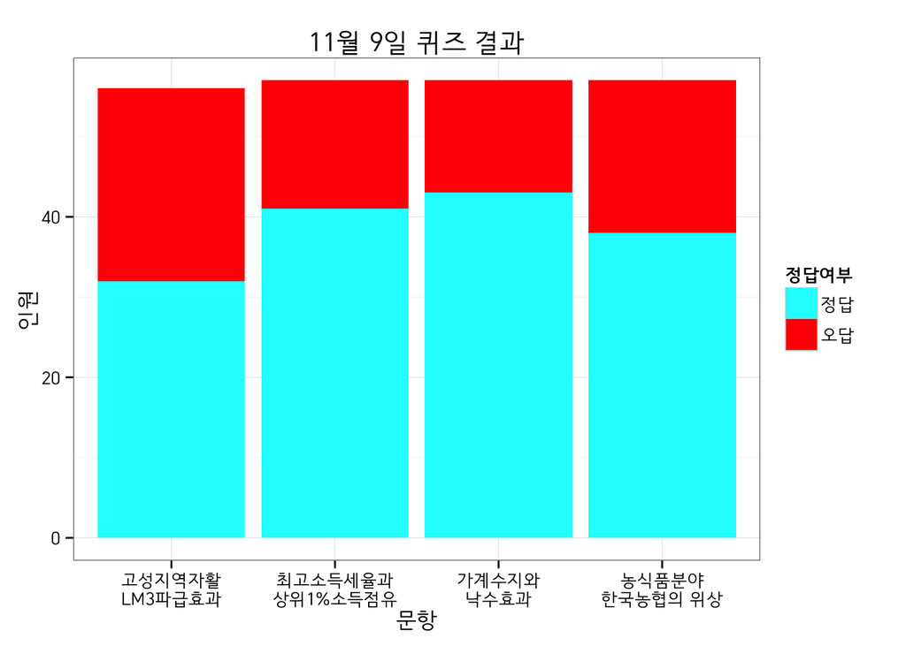

```r
(mtl.6 <- mtl.4 + scale_fill_manual(values=c("cyan", "red"), labels=c("정답", "오답")) + labs(fill="정답여부"))
```

- 범례 항목의 등장 순서를 바꾸려면,

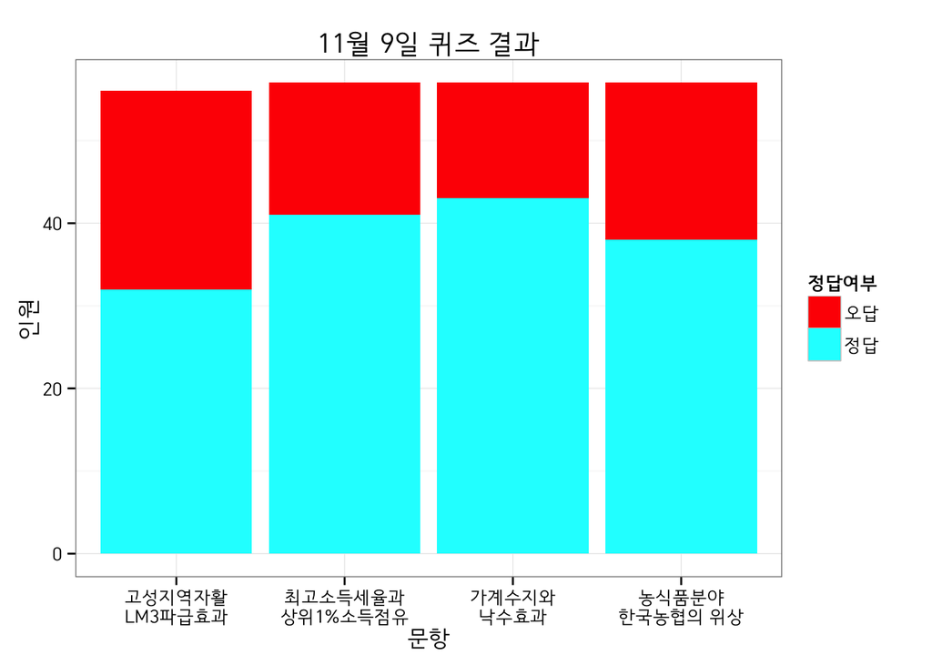

```r
(mtl.7 <- mtl.4 + scale_fill_manual(limits=c("W", "R"), values=c("red", "cyan"), labels=c("오답", "정답")) + labs(fill="정답여부"))
```

- 정답률을 각 막대에 새기기

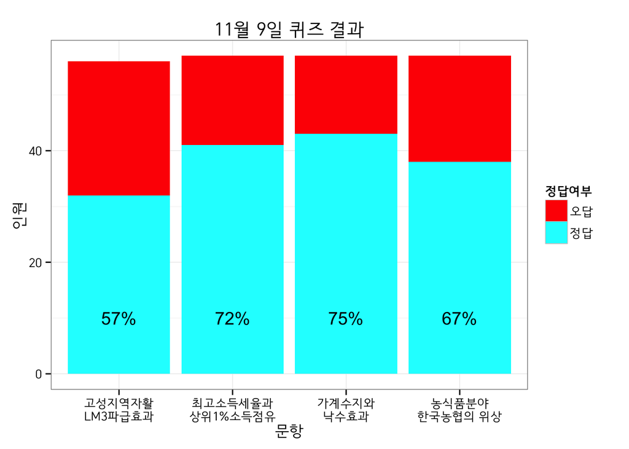

```r
(mtl.8 <- mtl.7 + annotate("text", x=1:4, y=rep(10, 4), label=paste(correct.ans.rate, "%", sep="")))
```

## 자료 갈무리

```r
save.image("quiz_1109v2.rda")
```